# Python Foundations Project: Austo

**Marks: 60**

## Problem Statement

### Context

In the 21st century, cars are an important mode of transportation that provides us the opportunity for personal control and autonomy. In day-to-day life, people use cars for commuting to work, shopping, visiting family and friends, etc. Research shows that more than 76% of people prevent themselves from traveling somewhere if they don't have a car. Most people tend to buy different types of cars based on their day-to-day necessities and preferences. So, it is essential for automobile companies to analyze the preference of their customers before launching a car model into the market. Austo, a UK-based automobile company aspires to grow its business into the US market after successfully establishing its footprints in the European market.

In order to be familiar with the types of cars preferred by the customers and factors influencing the car purchase behavior in the US market, Austo has contracted a consulting firm. Based on various market surveys, the consulting firm has created a dataset of 3 major types of cars that are extensively used across the US market. They have collected various details of the car owners which can be analyzed to understand the automobile market of the US.

### Objective

Austo's management team wants to understand the demand of the buyers and trends in the US market. They want to build customer profiles based on the analysis to identify new purchase opportunities so that they can manipulate the business strategy and production to meet certain demand levels. Further, the analysis will be a good way for management to understand the dynamics of a new market. Suppose you are a Data Scientist working at the consulting firm that has been contracted by Austo. You are given the task to create buyer's profiles for different types of cars with the available data as well as a set of recommendations for Austo. Perform the data analysis to generate useful insights that will help the automobile company to grow its business.

### Data Description

austo_automobile.csv: The dataset contains buyer's data corresponding to different types of products(cars).

### Data Dictionary

- Age: Age of the customer
- Gender: Gender of the customer
- Profession: Indicates whether the customer is a salaried or business person
- Marital_status: Marital status of the customer
- Education: Refers to the highest level of education completed by the customer
- No_of_dependents: Number of dependents(partner/children/spouse) of the customer
- Personal_loan: Indicates whether the customer availed a personal loan or not
- House_loan: Indicates whether the customer availed house loan or not
- Partner_working: Indicates whether the customer's partner is working or not
- Salary: Annual Salary of the customer
- Partner_salary: Annual Salary of the customer's partner
- Total_salary: Annual household income (Salary + Partner_salary) of the customer's family
- Price: Price of the car
- Make: Car type (Hatchback/Sedan/SUV)

## Importing necessary libraries

```python
# import libraries for data manipulation
import numpy as np
import pandas as pd

# import libraries for data visualization
import matplotlib.pyplot as plt
import seaborn as sns
#removes warnings about obsolete code, phrasing
import warnings
warnings.filterwarnings('ignore')
```

## Importing the dataset

```python
#mount drive / google collab
from google.colab import drive
drive.mount('/content/drive')
```

```python
# read the data
df = pd.read_csv('/content/drive/MyDrive/PGP_DSBA/Python Foundations/Case Studies/austo_automobile.csv')
# returns the first 5 rows
df.head()
```

|  | Age | Gender | Profession | Marital_status | Education | No_of_Dependents | Personal_loan | House_loan | Partner_working | Salary | Partner_salary | Total_salary | Price | Make |
| --- | --- | --- | --- | --- | --- | --- | --- | --- | --- | --- | --- | --- | --- | --- |
| 0 | 24 | Male | Salaried | Married | Post Graduate | 4 | No | Yes | Yes | 52000 | 25000 | 77000 | 18000 | Hatchback |
| 1 | 28 | Male | Salaried | Married | Post Graduate | 3 | No | Yes | No | 68000 | 0 | 68000 | 18000 | Hatchback |
| 2 | 23 | Male | Salaried | Married | Graduate | 4 | Yes | Yes | No | 31000 | 0 | 31000 | 18000 | Hatchback |
| 3 | 26 | Male | Business | Married | Post Graduate | 4 | Yes | Yes | Yes | 66000 | 35000 | 101000 | 18000 | Hatchback |
| 4 | 28 | Male | Business | Married | Post Graduate | 4 | Yes | No | No | 64000 | 0 | 64000 | 18000 | Hatchback |

## Data Overview

#### Question 1: How many rows and columns are present in the data? [0.5 mark]

```python
#displays the number of rows and columns in dataframe
df.shape
```

```
(1581, 14)
```

#### Observations: There are 1581 rows and 14 columns in this data set

#### Question 2: What are the datatypes of the different columns in the dataset? [0.5 mark]

```python
#display the names and data types for each column
df.info()
```

```
<class 'pandas.core.frame.DataFrame'>
RangeIndex: 1581 entries, 0 to 1580
Data columns (total 14 columns):
 #   Column            Non-Null Count  Dtype
---  ------            --------------  -----
 0   Age               1581 non-null   int64
 1   Gender            1581 non-null   object
 2   Profession        1581 non-null   object
 3   Marital_status    1581 non-null   object
 4   Education         1581 non-null   object
 5   No_of_Dependents  1581 non-null   int64
 6   Personal_loan     1581 non-null   object
 7   House_loan        1581 non-null   object
 8   Partner_working   1581 non-null   object
 9   Salary            1581 non-null   int64
 10  Partner_salary    1581 non-null   int64
 11  Total_salary      1581 non-null   int64
 12  Price             1581 non-null   int64
 13  Make              1581 non-null   object
dtypes: int64(6), object(8)
memory usage: 173.0+ KB
```

#### Observations:

- There are 6 integer data types and 8 object/categorical data types. All columns seem necessary at this time and seem appropriately typed. No floats are needed in this dataset.
- All columns have 1581 observations, that is not a guarantee that all data points are valid, but at least there are not any inherintly null values to demonstrate missing/blank.
- There are not units on the Price in the problem statement, but will assume USD since they are built on US buyer profiles.

#### Question 3: Check the statistical summary of the data. What is the minimu, avergae, and maximum Price of the cars? [2 marks]

```python
# Statistical summary of the int64 columns only
# Transposed is a formatting preference
df.describe().T
```

|  | count | mean | std | min | 25% | 50% | 75% | max |
| --- | --- | --- | --- | --- | --- | --- | --- | --- |
| Age | 1581.0 | 32.211259 | 9.125477 | 22.0 | 25.0 | 29.0 | 38.0 | 60.0 |
| No_of_Dependents | 1581.0 | 2.457938 | 0.943483 | 0.0 | 2.0 | 2.0 | 3.0 | 4.0 |
| Salary | 1581.0 | 59732.447818 | 14278.642665 | 30000.0 | 51000.0 | 59000.0 | 71000.0 | 90000.0 |
| Partner_salary | 1581.0 | 19720.430108 | 19480.214404 | 0.0 | 0.0 | 25000.0 | 38000.0 | 80000.0 |
| Total_salary | 1581.0 | 79452.877925 | 24855.936043 | 30000.0 | 61000.0 | 78000.0 | 96000.0 | 158000.0 |
| Price | 1581.0 | 35597.722960 | 13633.636545 | 18000.0 | 25000.0 | 31000.0 | 47000.0 | 70000.0 |

#### Observations:

- The minimum price of a car is 18,000 USD.
- The average price of a car is 35,598 USD.
- The maximum price of a car is 70,000 USD.
- The ages in this data are heavily right skewed - 50% of the data is from age 22 to 29, with the max age being 60 years old.
- The number of dependents show that all families have between 0 and 4 dependents.
- Between the age, number of dependents, and education data - most of this data set appears to be early career car purchases. Many of the purchases from age 22 to 29 are likely the first "new car" purchase made without parental/family help.

#### Question 4: Are there any missing values in the data? If yes, treat them using an appropriate method. [1 Mark]

```python
#We already know that all columns have 1581 non-null objects and there are 1581 rows of data
#but demonstrating this method of looking for nulls anyway
df.isnull().sum()
```

```
Age                 0
Gender              0
Profession          0
Marital_status      0
Education           0
No_of_Dependents    0
Personal_loan       0
House_loan          0
Partner_working     0
Salary              0
Partner_salary      0
Total_salary        0
Price               0
Make                0
dtype: int64
```

```python
#Are there any observations in the categorical data that are functionally representing missing values?
#Create dataframe of just objects columns
df_objs = df.select_dtypes(exclude=['int'])
#Print a count of each unique observation in every category
for col in df_objs.columns:
  print(df_objs[col].value_counts())
  print()                                 #formatting preference
```

```
Male      1252
Female     329
Name: Gender, dtype: int64

Salaried    896
Business    685
Name: Profession, dtype: int64

Married    1443
Single      138
Name: Marital_status, dtype: int64

Post Graduate    985
Graduate         596
Name: Education, dtype: int64

Yes    792
No     789
Name: Personal_loan, dtype: int64

No     1054
Yes     527
Name: House_loan, dtype: int64

Yes    868
No     713
Name: Partner_working, dtype: int64

Hatchback    884
Sedan        460
SUV          237
Name: Make, dtype: int64
```

#### Observations:

Does not appear to be any missing data or categorically named data that fucntions as missing data.

#### Question 5: How many cars are there of type SUV? [1 mark]

```python
# Also shown above, when looking at all categorical data.
# Here is one way to look at just one column / obsevation
df['Make'].value_counts().SUV
```

```
237
```

```python
#find the percent representation of the Make in the dataset
df['Make'].value_counts(normalize = True)
```

```
Hatchback    0.559140
Sedan        0.290955
SUV          0.149905
Name: Make, dtype: float64
```

#### Observations:

There are 237 SUV purchases, representing 15% of the dataset.

## Exploratory Data Analysis (EDA)

### Univariate Analysis

#### **Question 6:** Explore all the variables and provide observations on their distributions. (Generally, histograms, boxplots, countplots, etc. are used for univariate exploration.) [10 marks]

##### Observations on Age

- 50% of the buyers are between the ages of 22 and 29.
- 75% of the buyers are less than 39 years old
- Highly right skewed with a few outliers between ages 55 and 60. The median age is much graeter than the 50%/Q2 mark.

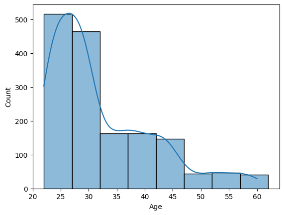

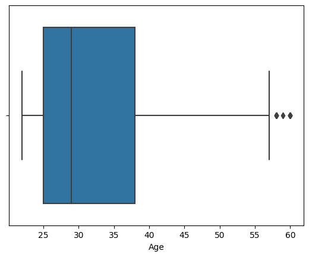

```python
#histplot and boxplot to show the distribution of continuously numeric data
#both show density of data in the distribution, in different visual ways
#boxplot shows outliers
sns.histplot(data=df,x = 'Age', kde = True, binwidth = 5)
plt.show()
sns.boxplot(data=df,x='Age')
plt.show()
```

##### Observations on Dependents

- Less than 2% of buyers in this data set have zero dependents. This is considered outlier in the data set. Thus, this company is looking at family vehicles.
- 70% of the buyers have either 2 or 3 dependents.

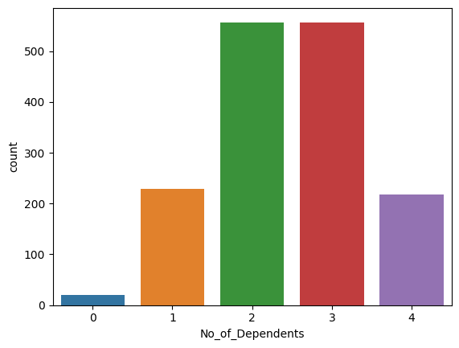

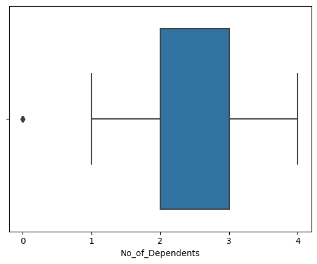

```python
#countplot used for discrete data
sns.countplot(data=df,x = 'No_of_Dependents')
plt.show()
#this forces the boxplot to display closer to the reality that
#the values are discrete instead of continuous
plt.xticks(np.arange(0, 5, step=1))
sns.boxplot(data=df,x='No_of_Dependents')
plt.show()
```

```python
#Percent composition of the data set to add to the above visualizations.
df['No_of_Dependents'].value_counts(normalize = True)
```

```
3    0.352309
2    0.352309
1    0.144845
4    0.137887
0    0.012650
Name: No_of_Dependents, dtype: float64
```

##### Observations on Salary

- Buyers have an annual income between 30k and 90k USD.
- The mean, mode, and Q2 are similar - around 59k USD.
- There is no real distribution, as the distribution is not symetrical around the mean, but there are three local maxima on the KDE around 37k, 59k and 73k.
- An additonal column was added to the data set to describe Salaries by their quartile position; low25, mid50, high25.

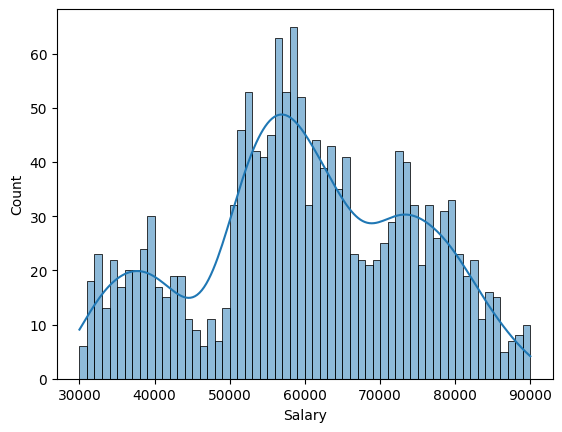

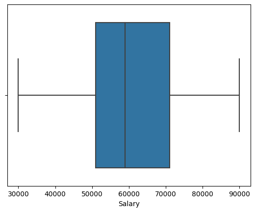

```python
sns.histplot(data=df,x='Salary', kde = True, binwidth = 1000)
plt.show()
#Using boxplot to visual quartile values
sns.boxplot(data=df,x='Salary')
plt.show()
```

For future multivariate analysis, making bins based on this roughly trimodal distribution of Salary. The histogram and the statistical analysis propose using the quartiles as the boundaries of the bins.

```python
#Create new column "Salary_bin" based on the definitions above
df['Salary_bin'] = pd.cut(df['Salary'],bins =[29999,51000,71000,90000], labels =['low25','mid50','high25'], right = True)
#check percent composition to check work. Including the right value aligns with quartiles.
print(df['Salary_bin'].value_counts(normalize = True))
```

```
mid50     0.499684
low25     0.251739
high25    0.248577
Name: Salary_bin, dtype: float64
```

##### Observations on Partner Salary

- The data shows almost 50% of partners as having 0 USD income, but this correstponds to the 713 buyers whose partner does not work (inlcuding the 138 buyers who are single). This is helpful to know in of itself, half of buyers are single-income homes.
- Of the partners that do work, 75% of have annual salary between 22k and 40k USD, with 59 outlier partners making 60k - 80k USD. Nearly all non-outlier partners would all be in the lowest quartile if they themselves were the buyers in the data set.
- Americans largely do not have access to state provided child, disabled, or eldercare; and given that most of these families have 2+ depenedents - there is a lot of unpaid labor in this data set. The lower partner incomes also could represent part time work, or the wage gap after pausing career for early child care.

```python
#Check my assumption that all "non working" partners have salary of $0.
df.groupby(by = ['Partner_working','Partner_salary'])['Age'].count()
```

```
Partner_working  Partner_salary
No               0                 713
Yes              22000               5
                 23000               8
                 24000              20
                 25000              82
                 26000              20
                 27000              17
                 28000              88
                 29000               2
                 30000             128
                 32000              44
                 35000              29
                 38000              95
                 40000             242
                 45000              14
                 50000              15
                 60000              24
                 70000              32
                 80000               3
Name: Age, dtype: int64
```

Assumption here was correct. Partner Working = no means a 0 USD income.

```python
#create new dataframe just including 2-income households; "Partner Works"
df.partworks = df.loc[df['Partner_working'] == 'Yes']
#investigate the statistical values of this subset
df.partworks['Partner_salary'].describe()
```

```
count      868.000000
mean     35919.354839
std      10441.596503
min      22000.000000
25%      28000.000000
50%      35000.000000
75%      40000.000000
max      80000.000000
Name: Partner_salary, dtype: float64
```

The average Partner Salary for those that work is 36k, with 50% of Partners making between 22k and 35k.

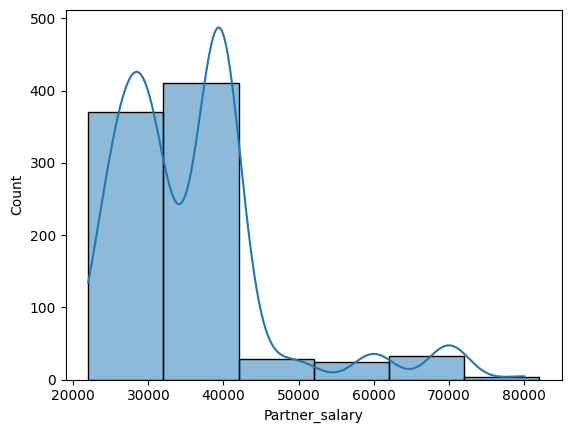

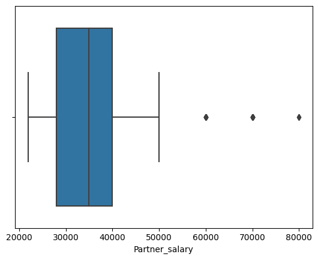

```python
#Visualizing the Working Partner data, since the full data has nearly 50% data = $0
sns.histplot(data=df.partworks,x='Partner_salary', kde = True, binwidth = 10000)
plt.show()
sns.boxplot(data=df.partworks,x='Partner_salary')
plt.show()
```

##### Observations of Total Salary (slight bivariate, including if Total Salary is from single to two income houses)

- There are buyers that have the minimum income of 30k and no partner income.
- The average total salary is 79.5k, which means the majority (more than 75%) of single income buyers are in the botton 50% of the total salary data.
- Single income families have an average of around 60K USD total salary while two income families have an average of around 100k USD total salary.
- Outliers are the two-income families making more than 150K

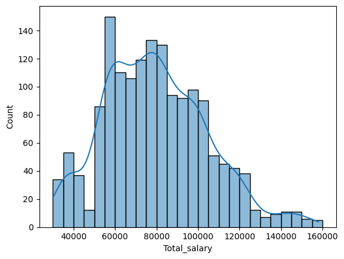

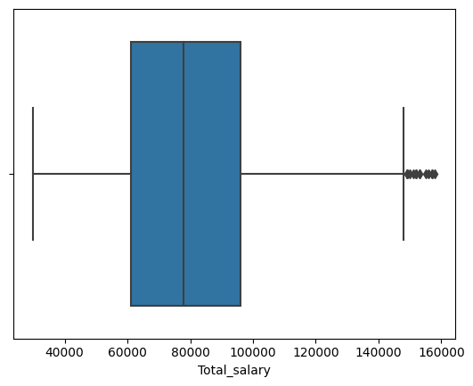

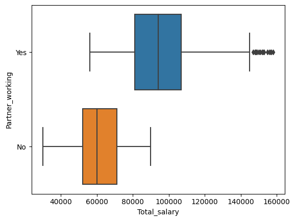

```python
sns.histplot(data=df,x='Total_salary', kde = True, binwidth = 5000)
plt.show()
sns.boxplot(data=df,x='Total_salary')
plt.show()
#slight multivariate interruption
sns.boxplot(data=df,x='Total_salary', y= 'Partner_working')
plt.show()
```

##### Observations on Price

- Prices on all vehicles range from 18k to 70k USD
- The average is 36k USD and the data is slighlty right-skewed, with 50% of cars less than 31k USD.

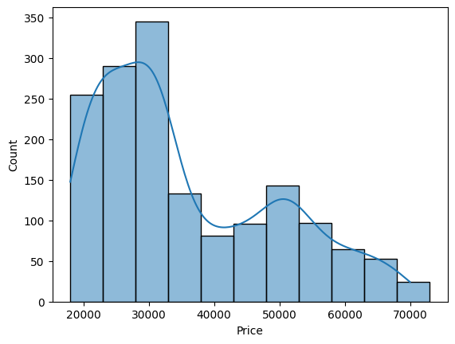

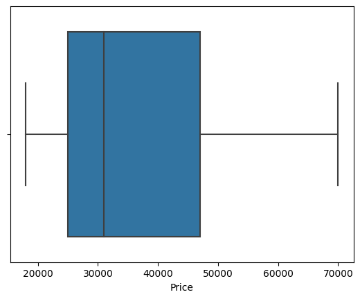

```python
sns.histplot(data=df,x='Price', kde = True, binwidth = 5000)
plt.show()
sns.boxplot(data=df,x='Price')
plt.show()
```

##### Observations on Demographic Data

```python
# This dataframe was made earlier when looking for missing values and general data overview
# This time presented as percentages
for col in df_objs.columns:
  print(df_objs[col].value_counts(normalize = True))
  print() #formatting preference
```

```
Male      0.791904
Female    0.208096
Name: Gender, dtype: float64

Salaried    0.56673
Business    0.43327
Name: Profession, dtype: float64

Married    0.912713
Single     0.087287
Name: Marital_status, dtype: float64

Post Graduate    0.623023
Graduate         0.376977
Name: Education, dtype: float64

Yes    0.500949
No     0.499051
Name: Personal_loan, dtype: float64

No     0.666667
Yes    0.333333
Name: House_loan, dtype: float64

Yes    0.54902
No     0.45098
Name: Partner_working, dtype: float64

Hatchback    0.559140
Sedan        0.290955
SUV          0.149905
Name: Make, dtype: float64
```

##### Observations on Make / Car Type

- Slight majority of the cars in this data set were Hatchbacks at 56%.
- Sedans were the next most popular at 29%, then SUVs at 15%

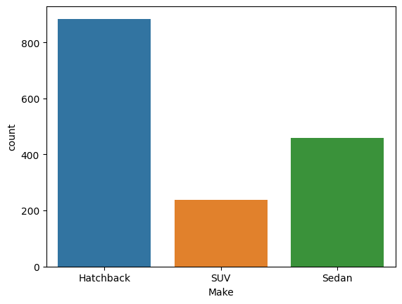

```python
sns.countplot(data=df, x = "Make")
```

#### Question 7: How many cars are of make Hatchback and priced above 25000. State your observations? [2 marks]

```python
#Select rows that are Hatchbacks greater than 25k, find size of dataframe
df.loc[(df.Make == "Hatchback") & (df.Price > 25000)].shape
```

```
(444, 15)
```

#### Observations:

There are 444 cars in the data set that are Hatchbacks priced above 25k USD, roughly half.

#### Question 8: How many owners have bought cars that were priced higher than their salary. How many of them have taken personal loan? [3 marks]

```python
#add a column finding the difference between Price and Total Salary
df['Difference'] = df['Price'] - df['Total_salary']
#values greater than 0 in Difference column are owners who bought cars priced higher than their total salary
print(df.loc[df.Difference > 0].shape)
#now just those with personal loans
print(df.loc[(df.Difference > 0) & (df.Personal_loan == "Yes")].shape)
```

```
(41, 16)
(19, 16)
```

```python
#grammar check - is the "them" in the second question referring to the first question, or generally?
df.loc[df.Personal_loan == "Yes"].shape
```

```
(792, 16)
```

#### Observations:

- There were 41 buyers whose vehicle cost more than their Total Salary. Of those, half (19 buyers) took personal loans. The non-loan buyers in this category are either excellent savers, had help from family, or have unreported income (etc).
- If the question meant to ask how many buyers - of all price points and spending habits - took personal loans, nearly half (792 buyers).

### Multivariate Analysis

#### Question 9: Perform a multivariate analysis to explore relationships between the important variables in the dataset. (It is a good idea to explore relations between numerical variables as well as relations between numerical and categorical variables) [15 marks]

##### Observations on numeric correlations

- The Price and Age in this dataset are highly correlated at 0.79. Older buyers are buying more expensive cars.
- The Price and Salary/TotalSalary correlations are positive, but lower at 0.39 and 0.35 respectively. This implies the pattern of buying a car might depend less on cost/salary and more on other factors.
- The Total Salary being more highly correlated to Partner Salary than to Salary makes sense; as the presence of a second income in half the data set would cause the $0 partner salaries to have a large effect on the total.
- The Age being more highly correlated to Salary than the Total Salary also makes sense; as the primary earners can expect to see an increase in salary as they age. Partner salaries, however, would not similarly correlate with age as many stay 0 USD through their lifetime or grow less rapidly than the primary earners - as seen with the 0.15 correlation value.

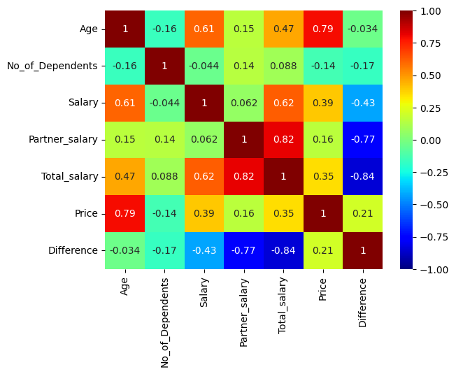

```python
#find correlations between numeric columns.
sns.heatmap(df.corr(),annot=True,cmap='jet',vmin=-1,vmax=1)
plt.show()
```

##### Observations on Car - specific Data

- Our only two data points on the cars themselves is the price and type of vehicle.
- The make of the care determines the price point
- Hatchbacks are the entry level vehicles, followed by Sedans, and the SUVs are essentially twice as expensive as the Hatchbacks

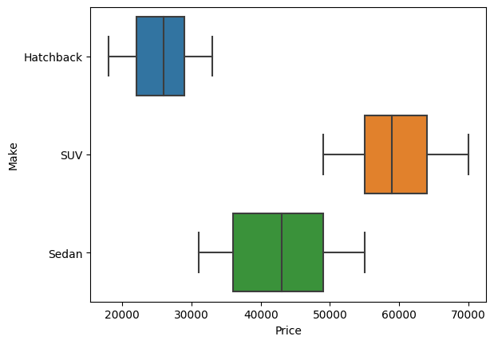

```python
sns.boxplot(data = df, x= 'Price', y = 'Make')
plt.show()
```

```python
#Gathering the numeric data to match the box plots
df.groupby(by = ['Make'])['Price'].describe()
```

| Make | count | mean | std | min | 25% | 50% | 75% | max |
| --- | --- | --- | --- | --- | --- | --- | --- | --- |
| Hatchback | 884.0 | 25561.085973 | 4425.257139 | 18000.0 | 22000.0 | 26000.0 | 29000.0 | 33000.0 |
| SUV | 237.0 | 59303.797468 | 5829.544340 | 49000.0 | 55000.0 | 59000.0 | 64000.0 | 70000.0 |
| Sedan | 460.0 | 42671.739130 | 7096.507565 | 31000.0 | 36000.0 | 43000.0 | 49000.0 | 55000.0 |

##### Observations of Demographic Data

- Female buyers have just slightly more buying power than male buyers, if they present themselves as the primary buyer.
- About half the data set utilizes personal loans, but none of the other demographics are strong predictors of choosing to finance their car.
- Number of dependents does not affect salary data. Larger families are working with the same annual income as a smaller family.
- Profession, Marital Status and Gender largely have no impact on Salary; but amount of education does. Post Graduate buyers have a larger lifetime salary, graduate buyers more likely to have quick increases in salary.

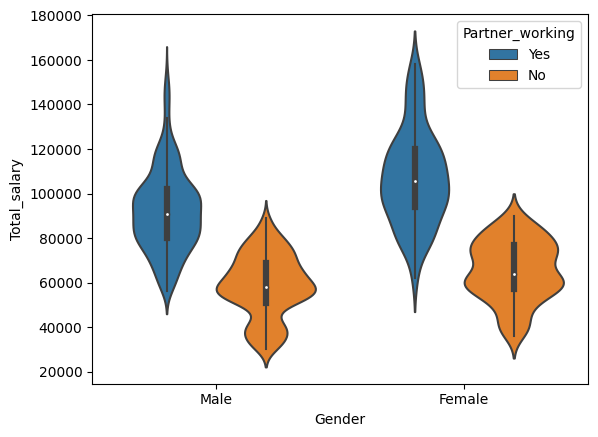

```python
#Is there a difference in buying power (totalsalary) between the genders, accounting for working partners?
sns.violinplot(data = df, x = "Gender", y= "Total_salary", hue = "Partner_working", split = False)
```

If the primary buyer is Female, they do have a larger Total Salary on average than the Male buyers. This is true in either case of the Partner working, but the average difference is greater in Female buyers with working partners.

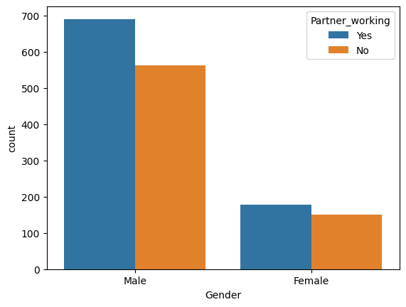

```python
#Is there a difference in partner working status across genders of primary buyers?
sns.countplot(data = df, x = "Gender", hue = "Partner_working")
```

```python
#Are the difference in height proportional?
df.groupby(by = ['Gender', 'Partner_working']).size()
```

```
Gender  Partner_working
Female  No                 151
        Yes                178
Male    No                 562
        Yes                690
dtype: int64
```

Both those colums show a 45%/55% split on not-working to working partners for both genders.

Next, lets look for patterns in Personal Loan usage:

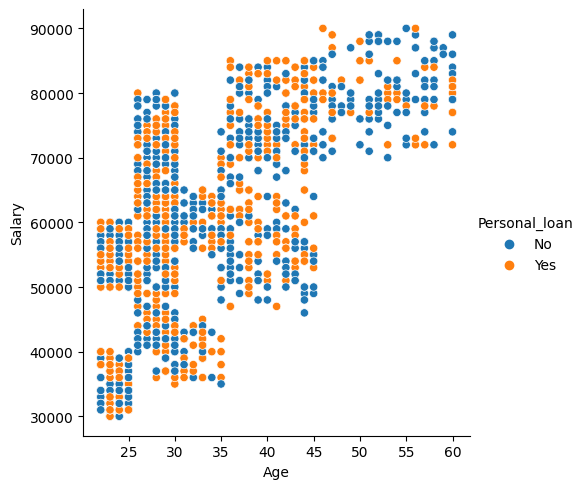

```python
#Do Salary or Age demonstrate a pattern on loan usage?
sns.relplot(data=df, x="Age", y="Salary", hue="Personal_loan")
```

No pattern observed. Income, Age do not predict use of Personal Loan.

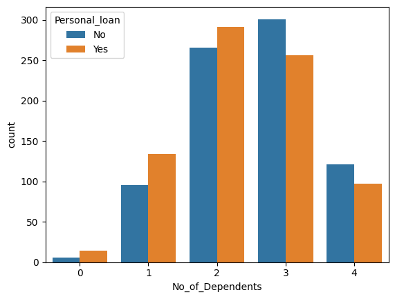

```python
#Check Number of Dependents
sns.countplot(data = df, x = "No_of_Dependents", hue = "Personal_loan")
```

We see a small shift in majority behavior in using Personal Loans - a third dependent causes a switch to less likely to be taking a personal loan.

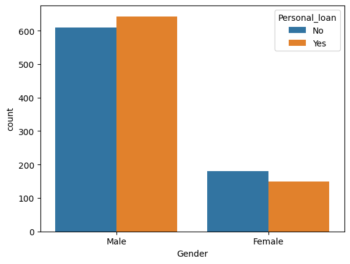

```python
#What about gender?
sns.countplot(data = df, x = "Gender", hue = "Personal_loan")
```

Again, a slight shift in majority. Female buyers less likely to utilize a personal loan.

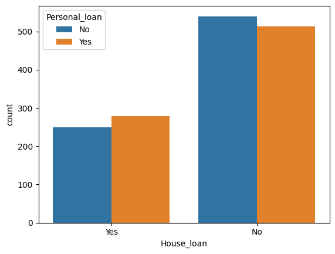

```python
#What about Home Loans - does using credit one way predit the other?
sns.countplot(data = df, x = "House_loan", hue = "Personal_loan")
```

We do see another slight majority - If someone has a house loan they are more likely to use a personal loan. None of these are huge percentage point differences, so will move from here.

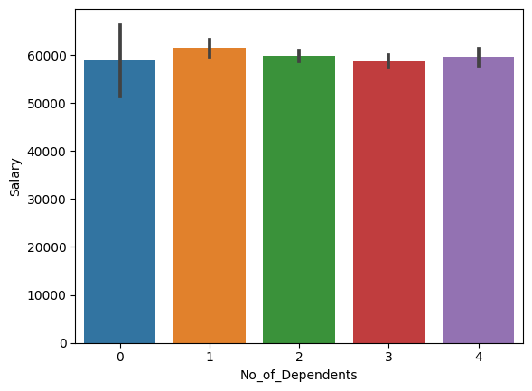

```python
#Does Number of Dependents have an effect on salary?
sns.barplot(data = df, x = 'No_of_Dependents', y = 'Salary')
```

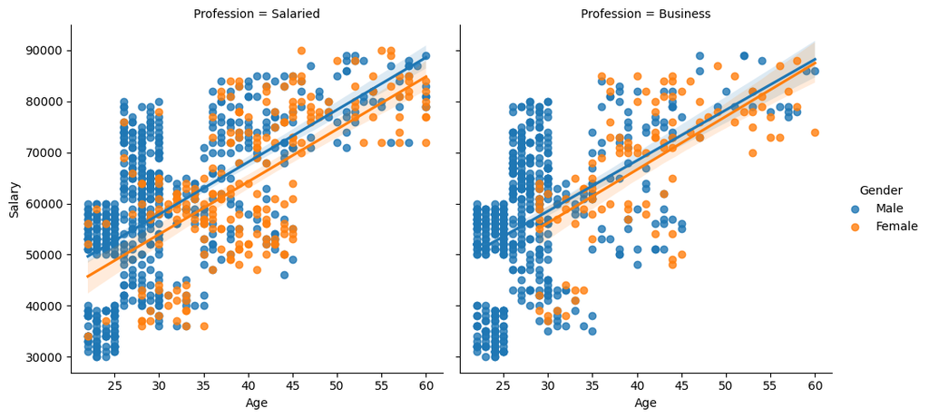

```python
#Does Profession have an effect on salary over time?
sns.lmplot(data = df, x = 'Age', y = 'Salary', hue = "Gender", col = 'Profession')
```

The pattern of data points are very similar. Generally profession does not have an impact on salary over time, but there is a smaller wage gap for Female buyers in the Business field.

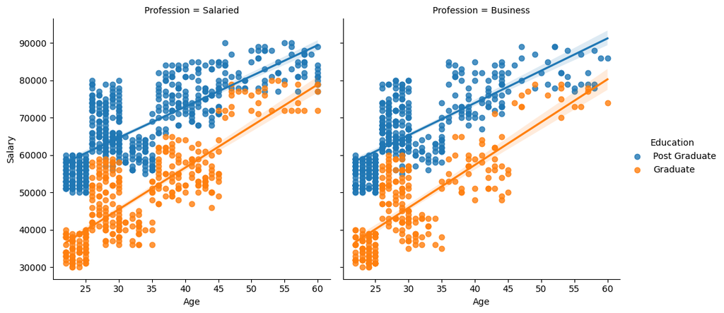

```python
#Does amount of education have an effect on salary over time?
sns.lmplot(data = df, x = 'Age', y = 'Salary', hue = 'Education', col = 'Profession')
```

Buyers with a Graduate level of education have a steeper increase in salary over time, and make less over their life time as comared to Post Graduates.

##### Observations on buying behavior

- Buying behavior is very tied to Age, followed secondly by number of dependents. Complete buyer profiles available in conclusions.
- Buying behavior is largely independent of Salary data, Marital Status, Personal Loans, House Loans, Working Partners, Education.
- No Pattern was found to explain pricing considerations; there appears to be no data driven reason why a buyer would buy (as an example) the 32k Hatchback over the 18k Hatchback.

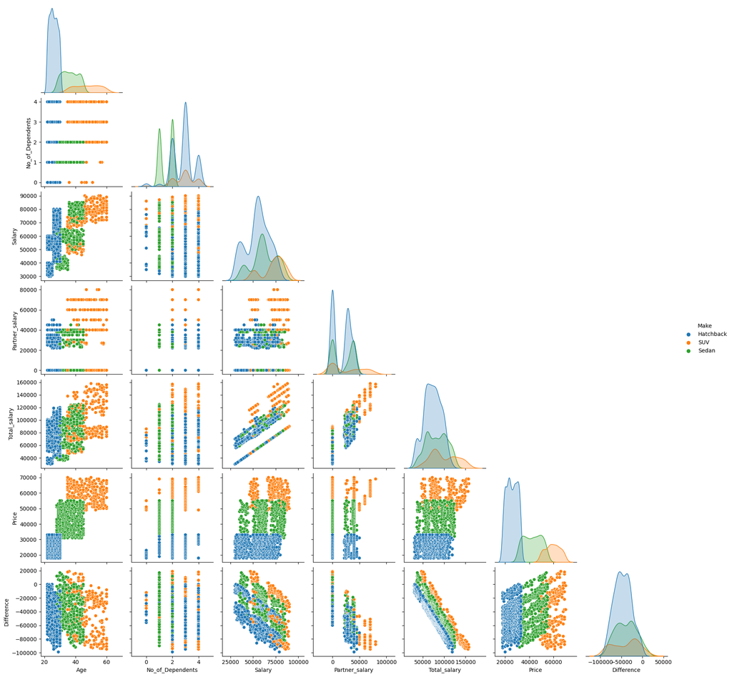

```python
#Get started with all data visualized, with respect to the Make since that is what we are trying to build profiles for
sns.pairplot(data=df, diag_kind="kde", hue = "Make", corner = True)
plt.show()
```

This gives us a starting position for several conversations.

> Age
- Buyers who spend more money than they make in a year tend to be 30-50 years old and buying Sedans and SUVs
- Older buyers are spending more money and they make more money. *Older buyers are more likely to have partners with high salaries.
- The dataset has a gap - there are no very few young 30's buyers with 3+ dependents. Their older and younger conterparts do.

> No of Dependents
- No correlation between number of dependents and spending habit (difference)
- Sedans are only purchased by families with 1-2 dependents
- No real correlation between number of dependents and salary data

> Salary Data
- Once someone makes 50k a year, they could be in the market for any of the three car types. There is a gentle trend of high salary, higher spending, but this is more to do with the age and number of dependents. The Salary KDE showing the three makes is an excellent visual of this.
- Partner Salary and Total Salary KDE graphs similary show that other factors are being used in buying decisions.

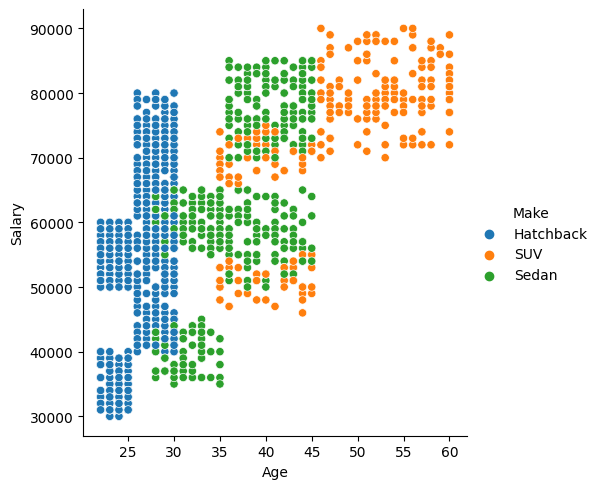

```python
#We know that Age and Salary are correlated; how do those metrics determine buying behavior?
sns.relplot(data=df, x="Age", y="Salary", hue="Make")
```

Clear age brackets here:

- Age 22-30, near exclusively purchasing Hatchbacks
- Age 30-35, near exclusively purchasing Sedans
- Age 35-45, still mostly purchasing Sedans, but small groups of SUV buyers
- Age 45-60, exclusively purchasing SUVs

There is some chunking happening in salary; based on exploration of education above that might be the cause. By "chunking", as an example; Sedan drivers aged 28-35 have two salary groupings.

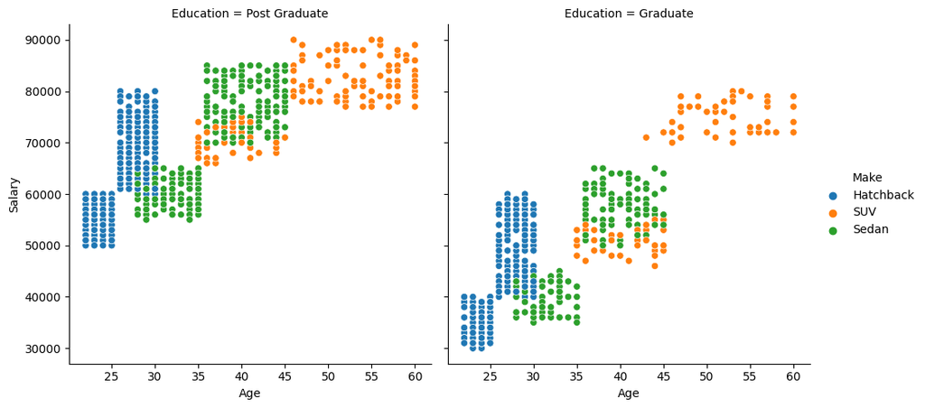

```python
#Any insights if we split that on education - will it explain the groupings we see above in the salaries and purchase decisions?
sns.relplot(data=df, x="Age", y="Salary", hue="Make", col = "Education")
```

The chunking/groupings to apepar to be based on education.